# Black Band Disease Metagenomics

Marine Genomics – MB5370

Austen Wong Won

20 July 2026

# 1 Background

## 1.1 Why black band disease matters

Black band disease (BBD) is a coral disease caused by a dense microbial mat that moves across living coral tissue. The mat is usually dominated by cyanobacteria, but it also contains sulfur-cycling and heterotrophic bacteria. Together, these organisms can create low-oxygen and sulfide-rich conditions at the coral surface, which contributes to tissue loss as the band moves across the colony (Sato et al., 2017).

BBD is important because it can cause rapid loss of live coral tissue and may become more damaging when corals are already stressed. Studying the whole microbial community is therefore more useful than looking for one pathogen. A metagenomic approach can show both **who is present** and **what metabolic functions the community may be capable of**.

## 1.2 What is already known

Previous work has shown that the BBD mat contains several broad functional groups:

- **Cyanobacteria**, which carry out photosynthesis and produce organic carbon.
- **Sulfate-reducing bacteria**, which can produce sulfide under low-oxygen conditions.
- **Sulfur-oxidising bacteria**, which use reduced sulfur compounds.
- **Heterotrophic bacteria**, which recycle organic matter and may support other members of the mat.

Sato et al. (2017) recovered a near-complete cyanobacterial genome from BBD and found strong photosynthetic activity. Their study also showed that Deltaproteobacteria, including *Desulfovibrio*-related organisms, were important members of the sulfur cycle.

## 1.3 Aim

The aim of this analysis was to assemble a BBD metagenome from Oxford Nanopore reads, recover draft microbial genomes, identify the main taxa, and test which bins contained genes linked to photosynthesis and sulfur cycling.

The main questions were:

1. How complete and contiguous was the BBD metagenome assembly?
2. Which microbial groups were represented in the strongest genome bins?
3. Which bins contained evidence for photosynthesis or sulfur-related pathways?
4. How did the results compare with the Illumina-based BBD study by Sato et al. (2017)?

# 2 Dataset

The reads came from a subset of a BBD sample collected by JCU PhD student Julia Hung in 2023 from an infected *Acropora hyacinthus* colony at Orpheus Island. High molecular weight DNA was extracted and sequenced using an Oxford Nanopore MinION. A subset of the full dataset was used for this workshop because the complete dataset would require more computing resources than were available for the class exercise.

I worked in a GitHub repository called `marine-genomics` and ran the main analyses through the JCU RStudio server using Slurm job scripts.

# 3 Processing log

This section includes the main commands used to generate and interpret the assembly. Routine commands used only to move between folders or inspect files have been left out.

## 3.1 Flye assembly

Flye was selected because it is designed for long-read assembly and has a metagenome mode for mixed microbial communities.

```bash
#!/bin/bash
#SBATCH --time=720
#SBATCH --ntasks=12 --mem=10gb

echo "Starting flye bbd in $(pwd) at $(date)"

flye --nano-hq bbd_0.1.fastq.gz \
     --threads 12 \
     --out-dir bbd \
     --meta

echo "Finished flye bbd in $(pwd) at $(date)"
```

The finished assembly was summarised with:

```bash
assembly-stats bbd/assembly.fasta
```

## 3.2 MetaBAT binning

MetaBAT grouped assembled contigs using coverage and sequence-composition information. The `--seed 5` option made the clustering reproducible.

```bash
cat ../flye/bbd/assembly_info.txt |
  grep -v '#' |
  awk '{OFS="\t"; print $1,$3}' > depths_bbd.txt

cat depths_bbd.txt |
  awk '{print $1}' |
  xargs samtools faidx ../flye/bbd/assembly.fasta \
  > assembly_bbd_ordered.fasta

metabat2 \
  -i assembly_bbd_ordered.fasta \
  -a depths_bbd.txt \
  --cvExt \
  -o bins_bbd/metabat \
  --seed 5
```

## 3.3 CheckM bin assessment

CheckM was used to estimate completeness and contamination from lineage-specific marker genes.

```bash
#!/bin/bash
#SBATCH --time=60
#SBATCH --ntasks=4 --mem=40gb

echo "Starting checkm in $(pwd) at $(date)"

shopt -s expand_aliases
alias checkm='apptainer run -B /pvol/:/pvol /pvol/data/sif/checkm.sif checkm'

checkm lineage_wf \
  bins_bbd \
  out \
  -t 4 \
  -x fa \
  -f checkm_results_bbd.txt

echo "Finished checkm in $(pwd) at $(date)"
```

Bins with more than 15% estimated completeness were selected for the functional analysis:

```bash
awk '$13 > 15 {print $1}' \
  checkm_results_bbd.txt \
  > bbd_topbins.txt
```

## 3.4 GTDB-Tk classification

GTDB-Tk placed the selected bins into a genome-based bacterial taxonomy.

```bash
#!/bin/bash
#SBATCH --time=60
#SBATCH --ntasks=2 --mem=24gb

echo "Starting gtdbtk in $(pwd) at $(date)"

shopt -s expand_aliases
alias gtdbtk='apptainer run -B /pvol:/pvol,/pvol/data/mg/gtdbtkdata/release207_v2/:/refdata /pvol/data/sif/gtdbtk.sif'

gtdbtk classify_wf \
  -x fa \
  --cpus 2 \
  --genome_dir genomes \
  --out_dir out \
  --skip_ani_screen

echo "Finished gtdbtk in $(pwd) at $(date)"
```

## 3.5 Prokka annotation

Prokka predicted genes and added available functional annotations to each selected bin.

```bash
#!/bin/bash
#SBATCH --time=60
#SBATCH --ntasks=2 --mem=2gb

echo "Starting prokka in $(pwd) at $(date)"

shopt -s expand_aliases
alias prokka='apptainer run -B /pvol/:/pvol /pvol/data/sif/prokka.sif prokka'

while read bin; do
  prokka \
    --outdir "$bin" \
    --prefix "$bin" \
    "../metabat/bins_bbd/${bin}.fa"
done < ../checkm/bbd_topbins.txt

echo "Finished prokka in $(pwd) at $(date)"
```

## 3.6 MinPath pathway inference

The EC numbers from Prokka were converted into one input file per bin. MinPath then inferred the smallest set of pathways that could explain the detected enzymes.

```bash
while read bin; do
  awk -F '\t' '$5 {printf("%s\t%s\n", $1,$5)}' \
    "../prokka/$bin/${bin}.tsv" |
    grep -v '^locus' > "${bin}.ec"
done < ../checkm/bbd_topbins.txt

while read bin; do
  minpath \
    -ec "${bin}.ec" \
    -report "${bin}.ec.report" \
    -details "${bin}.ec.details"
done < ../checkm/bbd_topbins.txt
```

The photosynthesis and tetrathionate-reduction results were checked using:

```bash
grep 'PWY-101' *.ec.report
grep 'PWY-5360' *.ec.report
```

# 4 Results

## 4.1 Assembly and binning

```r
assembly_summary <- data.frame(
  Metric = c(
    "Total assembly length",
    "Number of contigs",
    "Average contig length",
    "Largest contig",
    "N50",
    "MetaBAT bins",
    "Bins selected for annotation"
  ),
  Result = c(
    "66,580,369 bp",
    "7,972",
    "8,351.78 bp",
    "4,706,700 bp",
    "13,029 bp",
    "70",
    "16"
  )
)

knitr::kable(
  assembly_summary,
  caption = "Table 1. Summary of the BBD metagenome assembly and binning results."
)
```

Table 1. Summary of the BBD metagenome assembly and binning results.

| Metric | Result |
| --- | --- |
| Total assembly length | 66,580,369 bp |
| Number of contigs | 7,972 |
| Average contig length | 8,351.78 bp |
| Largest contig | 4,706,700 bp |
| N50 | 13,029 bp |
| MetaBAT bins | 70 |
| Bins selected for annotation | 16 |

The assembly was **66.58 Mb** long and contained **7,972 contigs**. The largest contig was **4.71 Mb**, but the N50 was only **13.03 kb**. This means that the assembly contained at least one very large sequence, while much of the remaining community was still split across smaller contigs. That is not unexpected for a real metagenome because the organisms occur at different abundances and may also contain closely related strains that are difficult to separate.

MetaBAT produced **70 bins**. Only **16 bins** had more than 15% estimated completeness, showing that most of the recovered bins were highly fragmented.

## 4.2 CheckM quality assessment

```r
checkm <- data.frame(
  Bin = c(
    "metabat.29", "metabat.56", "metabat.57", "metabat.38",
    "metabat.3", "metabat.12", "metabat.45", "metabat.33",
    "metabat.70", "metabat.16", "metabat.61", "metabat.65",
    "metabat.53", "metabat.24", "metabat.10", "metabat.41"
  ),
  Marker_lineage = c(
    "Cyanobacteria", "Clostridiales", "Bacteria", "Bacteria",
    "Deltaproteobacteria", "algicola", "Proteobacteria", "Clostridiales",
    "Bacteria", "Bacteria", "Bacteria", "Deltaproteobacteria",
    "Bacteria", "Bacteria", "Bacteria", "Deltaproteobacteria"
  ),
  Completeness = c(
    97.56, 33.22, 30.28, 29.31,
    28.18, 27.44, 26.77, 22.60,
    22.41, 21.55, 21.43, 20.79,
    19.73, 17.54, 15.52, 15.12
  ),
  Contamination = c(
    0.67, 1.77, 0.00, 0.00,
    0.13, 0.00, 0.00, 0.00,
    0.00, 0.00, 0.00, 0.00,
    0.00, 0.00, 0.00, 0.00
  )
)

knitr::kable(
  checkm,
  digits = 2,
  caption = "Table 2. CheckM results for the 16 bins with more than 15% estimated completeness."
)
```

Table 2. CheckM results for the 16 bins with more than 15% estimated completeness.

| Bin | Marker_lineage | Completeness | Contamination |
| --- | --- | --- | --- |
| metabat.29 | Cyanobacteria | 97.56 | 0.67 |
| metabat.56 | Clostridiales | 33.22 | 1.77 |
| metabat.57 | Bacteria | 30.28 | 0.00 |
| metabat.38 | Bacteria | 29.31 | 0.00 |
| metabat.3 | Deltaproteobacteria | 28.18 | 0.13 |
| metabat.12 | algicola | 27.44 | 0.00 |
| metabat.45 | Proteobacteria | 26.77 | 0.00 |
| metabat.33 | Clostridiales | 22.60 | 0.00 |
| metabat.70 | Bacteria | 22.41 | 0.00 |
| metabat.16 | Bacteria | 21.55 | 0.00 |
| metabat.61 | Bacteria | 21.43 | 0.00 |
| metabat.65 | Deltaproteobacteria | 20.79 | 0.00 |
| metabat.53 | Bacteria | 19.73 | 0.00 |
| metabat.24 | Bacteria | 17.54 | 0.00 |
| metabat.10 | Bacteria | 15.52 | 0.00 |
| metabat.41 | Deltaproteobacteria | 15.12 | 0.00 |

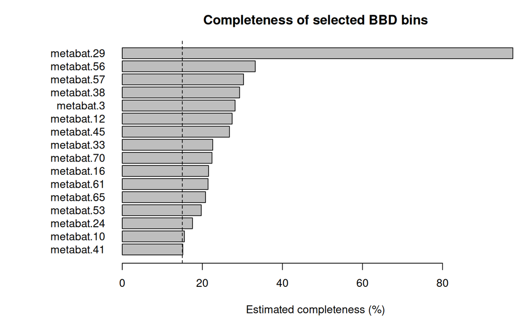

Figure 1. Estimated completeness of the 16 bins selected for downstream analysis. The dashed line shows the 15% selection threshold.

```r
plot_order <- order(checkm$Completeness)

par(mar = c(5, 9, 3, 1))

barplot(
  checkm$Completeness[plot_order],
  names.arg = checkm$Bin[plot_order],
  horiz = TRUE,
  las = 1,
  xlab = "Estimated completeness (%)",
  main = "Completeness of selected BBD bins"
)

abline(v = 15, lty = 2)
```

`metabat.29` was clearly the strongest bin. It had **97.56% completeness** and only **0.67% contamination**, making it the only near-complete genome recovered in this analysis. The next highest completeness was only 33.22%. This large gap suggests that the dominant organism assembled well, while most of the lower-abundance community remained fragmented.

## 4.3 Taxonomic composition

```r
taxonomy <- data.frame(
  Bin = c(
    "metabat.29",
    "metabat.12",
    "metabat.16",
    "metabat.38",
    "metabat.57",
    "metabat.3",
    "metabat.41"
  ),
  Phylum = c(
    "Cyanobacteria",
    "Bacteroidota",
    "Campylobacterota",
    "Campylobacterota",
    "Campylobacterota",
    "Desulfobacterota",
    "Desulfobacterota_I"
  ),
  Family = c(
    "Desertifilaceae",
    "Flavobacteriaceae",
    "Arcobacteraceae",
    "Arcobacteraceae",
    "Arcobacteraceae",
    "Desulforegulaceae",
    "Desulfovibrionaceae"
  ),
  Genus_or_species = c(
    "Roseofilum reptotaenium_A",
    "DT-34",
    "Poseidonibacter",
    "Halarcobacter",
    "Halarcobacter",
    "Unclassified genus",
    "Maridesulfovibrio"
  ),
  Completeness = c(
    97.56, 27.44, 21.55, 29.31, 30.28, 28.18, 15.12
  ),
  Contamination = c(
    0.67, 0.00, 0.00, 0.00, 0.00, 0.13, 0.00
  )
)

knitr::kable(
  taxonomy,
  digits = 2,
  caption = "Table 3. Curated GTDB-Tk classifications for bins most relevant to the BBD community and pathway interpretation."
)
```

Table 3. Curated GTDB-Tk classifications for bins most relevant to the BBD community and pathway interpretation.

| Bin | Phylum | Family | Genus_or_species | Completeness | Contamination |
| --- | --- | --- | --- | --- | --- |
| metabat.29 | Cyanobacteria | Desertifilaceae | Roseofilum reptotaenium_A | 97.56 | 0.67 |
| metabat.12 | Bacteroidota | Flavobacteriaceae | DT-34 | 27.44 | 0.00 |
| metabat.16 | Campylobacterota | Arcobacteraceae | Poseidonibacter | 21.55 | 0.00 |
| metabat.38 | Campylobacterota | Arcobacteraceae | Halarcobacter | 29.31 | 0.00 |
| metabat.57 | Campylobacterota | Arcobacteraceae | Halarcobacter | 30.28 | 0.00 |
| metabat.3 | Desulfobacterota | Desulforegulaceae | Unclassified genus | 28.18 | 0.13 |
| metabat.41 | Desulfobacterota_I | Desulfovibrionaceae | Maridesulfovibrio | 15.12 | 0.00 |

The largest and most complete part of the assembly was `metabat.29`, which GTDB-Tk classified as *Roseofilum reptotaenium_A*. This is a cyanobacterium in the family Desertifilaceae and is closely linked with BBD mats.

The other selected bins represented several groups that are also relevant to BBD, including Flavobacteriaceae, Arcobacteraceae, Desulforegulaceae and Desulfovibrionaceae. `metabat.41` was classified as *Maridesulfovibrio*, while `metabat.3` belonged to Desulforegulaceae. These are the strongest taxonomic candidates for sulfate reduction, although both bins were incomplete.

`metabat.10` could not be classified beyond Bacteria because GTDB-Tk reported too few aligned amino acids. This is consistent with its low CheckM completeness of 15.52%.

## 4.4 Prokka gene annotation

```r
prokka_summary <- read.delim(
  "prokka_gene_summary.tsv",
  header = TRUE,
  stringsAsFactors = FALSE
)

total_genes <- sum(prokka_summary$Genes)
genes_with_ec <- sum(prokka_summary$Genes_with_EC)
ec_percentage <- 100 * genes_with_ec / total_genes

knitr::kable(
  prokka_summary,
  caption = "Table 4. Number of Prokka gene records and EC-number annotations in each selected bin."
)
```

Table 4. Number of Prokka gene records and EC-number annotations in each selected bin.

| Bin | Genes | Genes_with_EC |
| --- | --- | --- |
| metabat.10 | 242 | 70 |
| metabat.12 | 834 | 192 |
| metabat.16 | 548 | 136 |
| metabat.24 | 941 | 318 |
| metabat.29 | 5561 | 1382 |
| metabat.33 | 400 | 142 |
| metabat.38 | 875 | 251 |
| metabat.3 | 746 | 227 |
| metabat.41 | 687 | 187 |
| metabat.45 | 1351 | 364 |
| metabat.53 | 480 | 131 |
| metabat.56 | 2599 | 566 |
| metabat.57 | 963 | 248 |
| metabat.61 | 570 | 165 |
| metabat.65 | 650 | 176 |
| metabat.70 | 509 | 147 |

Across the 16 selected bins, Prokka identified **17,956 gene records**. Of these, **4,702** were assigned an EC number, equal to **26.19%**.

The EC-number percentage is important because MinPath depends on these enzyme annotations. Around three quarters of the predicted genes did not receive an EC number, so the pathway analysis is likely to miss some real functions.

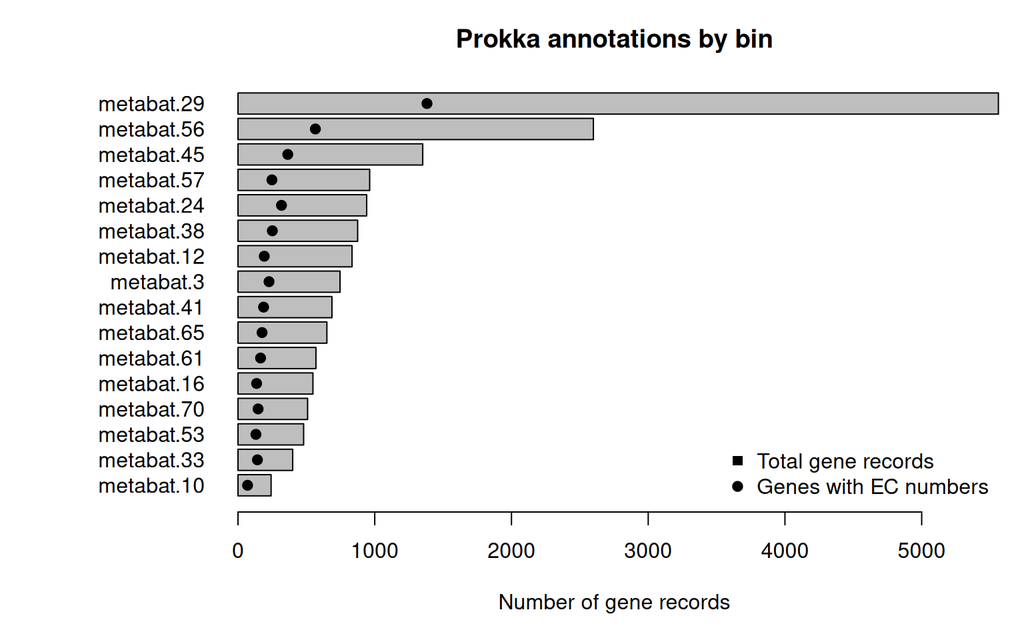

Figure 2. Total Prokka gene records in each selected bin. The points show the number of genes that received an EC-number annotation.

```r
gene_order <- order(prokka_summary$Genes)

par(mar = c(5, 9, 3, 1))

bar_positions <- barplot(
  prokka_summary$Genes[gene_order],
  names.arg = prokka_summary$Bin[gene_order],
  horiz = TRUE,
  las = 1,
  xlab = "Number of gene records",
  main = "Prokka annotations by bin"
)

points(
  prokka_summary$Genes_with_EC[gene_order],
  bar_positions,
  pch = 19
)

legend(
  "bottomright",
  legend = c("Total gene records", "Genes with EC numbers"),
  pch = c(15, 19),
  bty = "n"
)
```

`metabat.29` had the most genes, with **5,561 gene records**, including **1,382 with EC numbers**. This supports the CheckM result that it was the most complete genome recovered.

## 4.5 MinPath pathway results

```r
minpath_results <- data.frame(
  Pathway = c(
    "PWY-101: photosynthesis light reactions",
    "PWY-101: photosynthesis light reactions",
    "PWY-101: photosynthesis light reactions",
    "PWY-101: photosynthesis light reactions",
    "PWY-5360: tetrathionate reduction"
  ),
  Bin = c(
    "metabat.12",
    "metabat.29",
    "metabat.33",
    "metabat.61",
    "metabat.57"
  ),
  Families_found = c(
    "1 of 4",
    "4 of 4",
    "1 of 4",
    "1 of 4",
    "1 of 3"
  ),
  Retained_by_MinPath = c(
    "No",
    "Yes",
    "Yes",
    "No",
    "No"
  ),
  Interpretation = c(
    "Partial signal only",
    "Strongest evidence; complete family set",
    "Retained, but only one family detected",
    "Partial signal only",
    "Weak and incomplete signal"
  )
)

knitr::kable(
  minpath_results,
  caption = "Table 5. MinPath results for the two pathways targeted in the workshop."
)
```

Table 5. MinPath results for the two pathways targeted in the workshop.

| Pathway | Bin | Families_found | Retained_by_MinPath | Interpretation |
| --- | --- | --- | --- | --- |
| PWY-101: photosynthesis light reactions | metabat.12 | 1 of 4 | No | Partial signal only |
| PWY-101: photosynthesis light reactions | metabat.29 | 4 of 4 | Yes | Strongest evidence; complete family set |
| PWY-101: photosynthesis light reactions | metabat.33 | 1 of 4 | Yes | Retained, but only one family detected |
| PWY-101: photosynthesis light reactions | metabat.61 | 1 of 4 | No | Partial signal only |
| PWY-5360: tetrathionate reduction | metabat.57 | 1 of 3 | No | Weak and incomplete signal |

Four bins contained at least one gene family associated with the photosynthesis light-reaction pathway. However, only `metabat.29` contained **all four of four families**. Its classification as *Roseofilum reptotaenium_A* makes this result biologically consistent with the cyanobacterial role in the BBD mat.

Only `metabat.57` contained a signal for PWY-5360, the tetrathionate-reduction superpathway. It contained only **one of three** families and MinPath did not retain the full pathway. This is therefore weak evidence and should not be treated as proof of a complete tetrathionate-reduction pathway.

# 5 Discussion

## 5.1 Assembly quality

The assembly recovered a large amount of microbial sequence data, including a 4.71 Mb contig and one near-complete cyanobacterial genome. However, the low N50 and the large number of contigs show that the full community was still fragmented.

The difference between `metabat.29` and the remaining bins is one of the clearest results. The dominant cyanobacterium had enough coverage to assemble into a near-complete genome, while most other community members were recovered only as partial genomes. This shows why a single assembly-wide statistic cannot fully describe metagenome quality. N50 describes overall contiguity, while CheckM gives a more useful estimate of how well individual microbial genomes were recovered.

## 5.2 Comparison with Sato et al. (2017)

Sato et al. used Illumina short reads to investigate BBD from *Montipora hispida* at Pelorus Island. The current analysis used a subset of Oxford Nanopore reads from *Acropora hyacinthus* at Orpheus Island. The samples, coral hosts, sequencing methods and binning workflows were therefore different, so the comparison is useful but not exact.

```r
sato_comparison <- data.frame(
  Broad_group = c(
    "BBD cyanobacterium",
    "Arcobacteraceae / Campylobacterales",
    "Flavobacteriaceae"
  ),
  This_analysis = c(
    "metabat.29: Roseofilum reptotaenium_A",
    "metabat.57: Halarcobacter",
    "metabat.12: DT-34"
  ),
  This_completeness = c(97.56, 30.28, 27.44),
  This_contamination = c(0.67, 0.00, 0.00),
  This_genes = c(5561, 963, 834),
  Sato_bin = c(
    "Cya2: BBD cyanobacterium",
    "Cam: Arcobacter",
    "Fla2: Flavobacteriaceae"
  ),
  Sato_completeness = c(99.33, 27.33, 35.20),
  Sato_contamination = c(0.20, 0.40, 0.90),
  Sato_genes = c(5452, 659, 1112)
)

knitr::kable(
  sato_comparison,
  digits = 2,
  caption = "Table 6. Broad comparison with selected genomic bins reported by Sato et al. (2017). The non-cyanobacterial comparisons are at broad taxonomic level and should not be treated as the same genomes."
)
```

Table 6. Broad comparison with selected genomic bins reported by Sato et al. (2017). The non-cyanobacterial comparisons are at broad taxonomic level and should not be treated as the same genomes.

| Broad_group | This_analysis | This_completeness | This_contamination | This_genes | Sato_bin | Sato_completeness | Sato_contamination | Sato_genes |
| --- | --- | --- | --- | --- | --- | --- | --- | --- |
| BBD cyanobacterium | metabat.29: Roseofilum reptotaenium_A | 97.56 | 0.67 | 5561 | Cya2: BBD cyanobacterium | 99.33 | 0.2 | 5452 |
| Arcobacteraceae / Campylobacterales | metabat.57: Halarcobacter | 30.28 | 0.00 | 963 | Cam: Arcobacter | 27.33 | 0.4 | 659 |
| Flavobacteriaceae | metabat.12: DT-34 | 27.44 | 0.00 | 834 | Fla2: Flavobacteriaceae | 35.20 | 0.9 | 1112 |

The strongest match was the cyanobacterium. `metabat.29` was 97.56% complete with 0.67% contamination and 5,561 predicted genes. Sato et al.’s Cya2 bin was 99.33% complete with 0.20% contamination and 5,452 genes. The results are very similar, even though the studies used different samples and sequencing methods. This supports the conclusion that a *Roseofilum*-related cyanobacterium was the dominant and most successfully recovered member of this BBD community.

Broad matches were also found for Arcobacteraceae and Flavobacteriaceae, but these bins were incomplete in both datasets. The present assembly did not recover clear near-complete equivalents for several of the high-completeness Alphaproteobacteria, Cytophagales, Alteromonadaceae and Gammaproteobacteria bins reported by Sato et al. This may reflect differences in the microbial communities, the reduced read subset used here, or the assembly and binning methods.

## 5.3 Photosynthesis

The MinPath result for photosynthesis was the clearest functional result. `metabat.29` contained all four gene families assigned to PWY-101 and was also the near-complete *Roseofilum* bin. This links the taxonomic and functional results: the dominant cyanobacterium was the main organism with evidence for carrying out the light reactions of photosynthesis.

The three other bins with a PWY-101 match each contained only one of four families. These partial hits are not enough to conclude that those organisms perform complete photosynthesis.

## 5.4 Sulfur cycling and sulfate reduction

The sulfur result needs more careful interpretation. PWY-5360 represents tetrathionate reduction, which is part of sulfur cycling but is not the same as sulfate reduction. `metabat.57`, classified as *Halarcobacter* in Arcobacteraceae, contained one of three PWY-5360 families. Since MinPath did not retain the complete pathway, this result only suggests limited sulfur-related potential.

Based on taxonomy, `metabat.41` (*Maridesulfovibrio*, Desulfovibrionaceae) and `metabat.3` (Desulforegulaceae) are the most likely sulfate-reduction candidates. Their CheckM completeness values were only 15.12% and 28.18%, so missing sulfate-reduction genes could be caused by incomplete genome recovery rather than true absence. This agrees with the general BBD model, where sulfate-reducing bacteria contribute to sulfide production within the mat.

## 5.5 Limitations

There are several limitations that affect how strongly these results can be interpreted:

1. **Only a subset of the Nanopore data was analysed.** Lower-abundance genomes may not have had enough coverage for complete assembly.
2. **Most bins were incomplete.** A pathway can appear absent simply because the relevant genes were not assembled into the bin.
3. **Only 26.19% of Prokka gene records received EC numbers.** MinPath could only use the genes with recognised enzyme annotations.
4. **MinPath uses a parsimonious model.** Its output is a prediction of the smallest pathway set that explains the detected enzymes, not direct evidence that a pathway was active.
5. **The largest unbinned contig was not added as a separate CheckM input in this run.** The workshop guide recommends doing this because MetaBAT can leave the largest contig unbinned. A genome mainly represented by that contig may therefore have been missed from the CheckM and GTDB-Tk results.
6. **This was one sample from one place and time.** The results should not be treated as a complete description of BBD communities across coral species or reefs.

# 6 Troubleshooting and workflow evaluation

The main technical problems happened during job management and MinPath preparation.

When the GTDB-Tk job first entered the Slurm queue, it showed `InvalidAccount`. The same message appeared for several other users, so I checked the queue again instead of resubmitting the job. The status later changed to running and the job completed normally. This avoided creating duplicate jobs that could overwrite the same output folder.

My first MinPath input loop failed because I pasted the loop more than once into the same terminal command. I checked the output with `ls *.ec | wc -l` and found that no EC files had been created. I then reran one clean loop and confirmed that all 16 input files were present.

I also stopped MinPath with `Ctrl+C` after only five reports had finished. Rather than rerunning completed bins, I used a conditional loop that skipped reports that already existed and ran only the missing ones:

```bash
while read bin; do
  if [ ! -s "${bin}.ec.report" ]; then
    minpath \
      -ec "${bin}.ec" \
      -report "${bin}.ec.report" \
      -details "${bin}.ec.details"
  fi
done < ../checkm/bbd_topbins.txt
```

The final check returned 16 reports. This was a useful example of checking intermediate outputs before repeating a long workflow.

# 7 Conclusion

This workflow recovered one near-complete BBD cyanobacterial genome and several partial genomes from other members of the microbial mat. The strongest bin, `metabat.29`, was classified as *Roseofilum reptotaenium_A*, had 97.56% completeness, contained 5,561 predicted genes, and carried the full set of gene families detected for the photosynthesis light-reaction pathway.

The sulfur-cycling results were less complete. `metabat.57` had a weak tetrathionate-reduction signal, while `metabat.41` and `metabat.3` were the strongest sulfate-reduction candidates based on taxonomy. Their low completeness means that the absence of a complete pathway cannot be treated as evidence that sulfate reduction was absent.

Overall, the analysis showed how assembly, binning, quality assessment, taxonomy and functional annotation need to be interpreted together. It also showed that strong biological conclusions should be based on both pathway evidence and genome quality, rather than on a single software output.

# 8 Reproducibility and repository organisation

The main reproducible files retained in the GitHub repository are:

```
04_bbd_metagenomics.Rmd
flye/run_flye_bbd.sh
checkm/run_checkm_bbd.sh
checkm/checkm_results_bbd.txt
checkm/bbd_topbins.txt
gtdbtk/run_gtdbtk.sh
prokka/run_prokka.sh
prokka_gene_summary.tsv
pathway_summary.txt
```

Large raw and generated files, including FASTQ reads, Flye assemblies, genome bins, GTDB-Tk outputs and Prokka output folders, were excluded using `.gitignore`. This keeps the repository readable while retaining the scripts and summary files needed to understand and reproduce the workflow.

[View the marine-genomics GitHub repository](https://github.com/Austen2001/marine-genomics)

# 9 References

Chaumeil, P.-A., Mussig, A. J., Hugenholtz, P., & Parks, D. H. (2020). GTDB-Tk: a toolkit to classify genomes with the Genome Taxonomy Database. *Bioinformatics*, 36(6), 1925–1927. https://doi.org/10.1093/bioinformatics/btz848

Kang, D. D., Froula, J., Egan, R., & Wang, Z. (2015). MetaBAT, an efficient tool for accurately reconstructing single genomes from complex microbial communities. *PeerJ*, 3, e1165. https://doi.org/10.7717/peerj.1165

Parks, D. H., Imelfort, M., Skennerton, C. T., Hugenholtz, P., & Tyson, G. W. (2015). CheckM: assessing the quality of microbial genomes recovered from isolates, single cells, and metagenomes. *Genome Research*, 25(7), 1043–1055. https://doi.org/10.1101/gr.186072.114

Sato, Y., Ling, E. Y. S., Turaev, D., Laffy, P., Weynberg, K. D., Rattei, T., Willis, B. L., & Bourne, D. G. (2017). Unraveling the microbial processes of black band disease in corals through integrated genomics. *Scientific Reports*, 7, 40455. https://doi.org/10.1038/srep40455

Seemann, T. (2014). Prokka: rapid prokaryotic genome annotation. *Bioinformatics*, 30(14), 2068–2069. https://doi.org/10.1093/bioinformatics/btu153